# JSC370H1 - Assignment 3

# Part 1

```r
query <- GET(url = "https://api.nasa.gov/neo/rest/v1/feed", query = list(start_date = "2024-03-01", end_date = "2024-03-08", api_key = "Jyr4bwi75CTrtmzGLjzvSrDkiEueIfhAhFnP8k1N"))

query <- fromJSON(httr::content(query, "text"), flatten = TRUE)
```

I retrieved 145 near Earth objects for the time period 2024-03-01 to 2024-03-08. Each object in the query has an associated URL, ID, name, and recorded attributes such as estimated diameter, relative velocity, and miss distance from Earth.

```r
# Adding relative velocity to each asteroid
for (i in 1:8) {
  query$near_earth_objects[[i]]$rv_kmph <- as.numeric(bind_rows(query$near_earth_objects[[i]]$close_approach_data)$relative_velocity.kilometers_per_hour)
}

# Concatenating all dataframes for each date and selecting key variables
asteroids_data <- bind_rows(query$near_earth_objects, .id = "date") |>
  rename(diameter_min = 11, diameter_max = 12,
         is_hazardous = is_potentially_hazardous_asteroid,
         relative_velocity = rv_kmph) |>
  mutate(diameter = (diameter_min + diameter_max) / 2) |>
  select(date, id, diameter, is_hazardous, relative_velocity)

# Creating the table
asteroids_data[order(as.Date(asteroids_data$date,
                             format = "%Y-%m-%d")),] |>
  kbl(row.names = FALSE) |>
  kable_styling(full_width = T) |>
  scroll_box(height = "300px")
```

| date | id | diameter | is_hazardous | relative_velocity |
| --- | --- | --- | --- | --- |
| 2024-03-01 | 2366470 | 0.5414304 | FALSE | 63830.422 |
| 2024-03-01 | 3008376 | 0.3416195 | FALSE | 12434.231 |
| 2024-03-01 | 3275974 | 0.0215547 | FALSE | 53476.804 |
| 2024-03-01 | 3428255 | 0.1036436 | FALSE | 74576.713 |
| 2024-03-01 | 3545552 | 0.0089031 | FALSE | 38317.571 |
| 2024-03-01 | 3581238 | 0.3711441 | FALSE | 70908.650 |
| 2024-03-01 | 3645267 | 0.1275095 | FALSE | 10126.176 |
| 2024-03-01 | 3701880 | 0.0187734 | FALSE | 37657.819 |
| 2024-03-01 | 3743744 | 0.0846336 | FALSE | 67811.700 |
| 2024-03-01 | 3803762 | 0.6691795 | FALSE | 128320.140 |
| 2024-03-01 | 3840796 | 0.0707201 | FALSE | 17239.212 |
| 2024-03-01 | 3840846 | 0.3072859 | FALSE | 50164.507 |
| 2024-03-01 | 3843636 | 0.0475929 | FALSE | 28835.998 |
| 2024-03-01 | 54054411 | 0.0517062 | FALSE | 43773.171 |
| 2024-03-01 | 54102019 | 0.0906865 | FALSE | 30380.776 |
| 2024-03-01 | 54198830 | 0.0366052 | FALSE | 56840.512 |
| 2024-03-01 | 54353620 | 0.0270111 | FALSE | 12866.480 |
| 2024-03-01 | 54416847 | 0.1424107 | FALSE | 44287.610 |
| 2024-03-01 | 54429272 | 0.0280636 | FALSE | 22869.296 |
| 2024-03-01 | 54429767 | 0.0231922 | FALSE | 26762.781 |
| 2024-03-01 | 54431183 | 0.1351271 | FALSE | 55226.191 |
| 2024-03-01 | 54431498 | 0.0252896 | FALSE | 21621.949 |
| 2024-03-01 | 54431500 | 0.0297127 | FALSE | 16192.760 |
| 2024-03-02 | 2448818 | 1.1790782 | FALSE | 41471.380 |
| 2024-03-02 | 2539856 | 0.2815416 | FALSE | 69838.575 |
| 2024-03-02 | 3071939 | 0.0985241 | FALSE | 54818.746 |
| 2024-03-02 | 3069758 | 0.0707201 | FALSE | 52698.055 |
| 2024-03-02 | 3160748 | 0.0065094 | FALSE | 30841.988 |
| 2024-03-02 | 3289172 | 0.0124035 | FALSE | 27205.659 |
| 2024-03-02 | 3556127 | 0.0108030 | FALSE | 25995.069 |

[output cut: 115 more lines]

Note that above, the diameter is recorded in kilometers and the relative velocity is recorded in kilometers per hour.

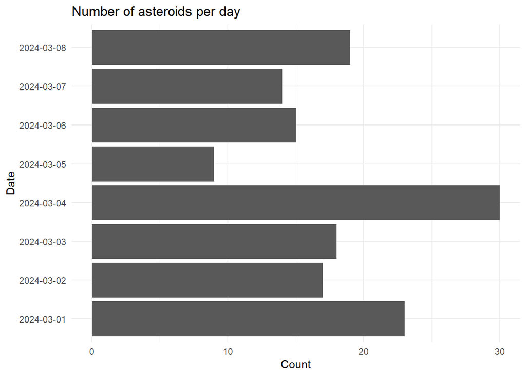

```r
# Exploring number of asteroids per day
asteroids_data |>
  count(date) |>
  ggplot(aes(x = date, y = n)) +
  geom_bar(stat = 'identity') +
  coord_flip() +
  labs(title = "Number of asteroids per day", x = "Date", y = "Count")
```

The number of asteroids fluctuates for each date, indicating that this number is likely not correlated from one day to the next. This is expected since asteroids travel from many different sources and hence approach Earth at many different times.

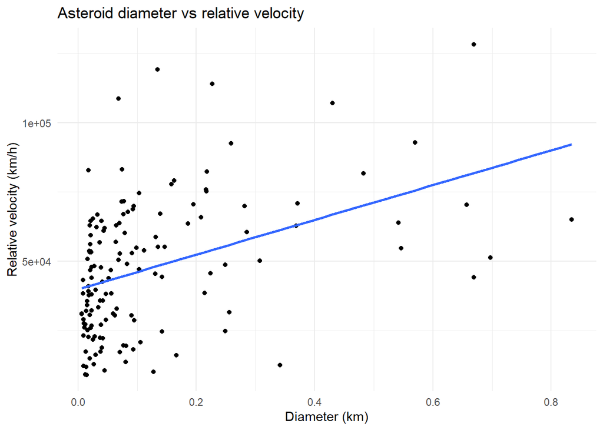

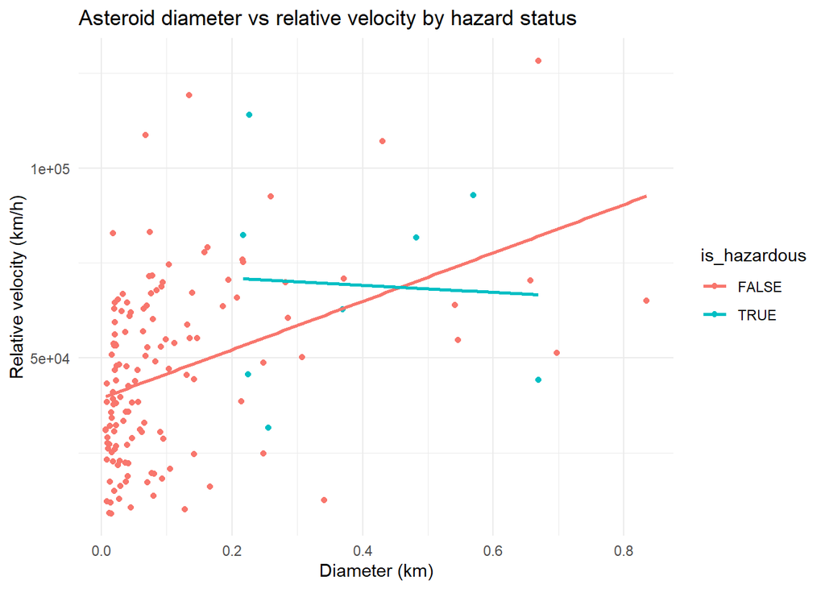

```r
asteroids_data |>
  filter(diameter < 1) |>
  ggplot(aes(x = diameter, y = relative_velocity)) +
  geom_point() +
  geom_smooth(method = 'lm', formula = y ~ x, se = FALSE) +
  labs(title = "Asteroid diameter vs relative velocity",
       x = "Diameter (km)", y = "Relative velocity (km/h)")

asteroids_data |>
  filter(diameter < 1) |>
  ggplot(aes(x = diameter, y = relative_velocity, color = is_hazardous)) +
  geom_point() +
  geom_smooth(method = 'lm', formula = y ~ x, se = FALSE) +
  labs(title = "Asteroid diameter vs relative velocity by hazard status",
       x = "Diameter (km)", y = "Relative velocity (km/h)")
```

I created scatterplots to see if asteroid diameter and relative velocity are related, and if `is_hazardous` has an effect. Since most observations have diameter less than 1 km, I removed three outliers with diameter greater than 1 km. The plots show that relative velocity generally increases with diameter. For non-hazardous asteroids, this holds. For hazardous asteroids, relative velocity decreases as diameter increases, but the association appears to be weak and there are few observations in the group, indicating low confidence in this finding.

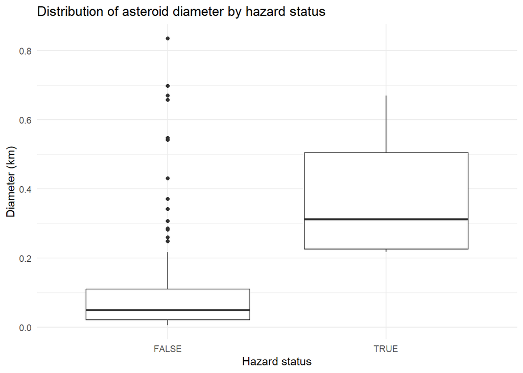

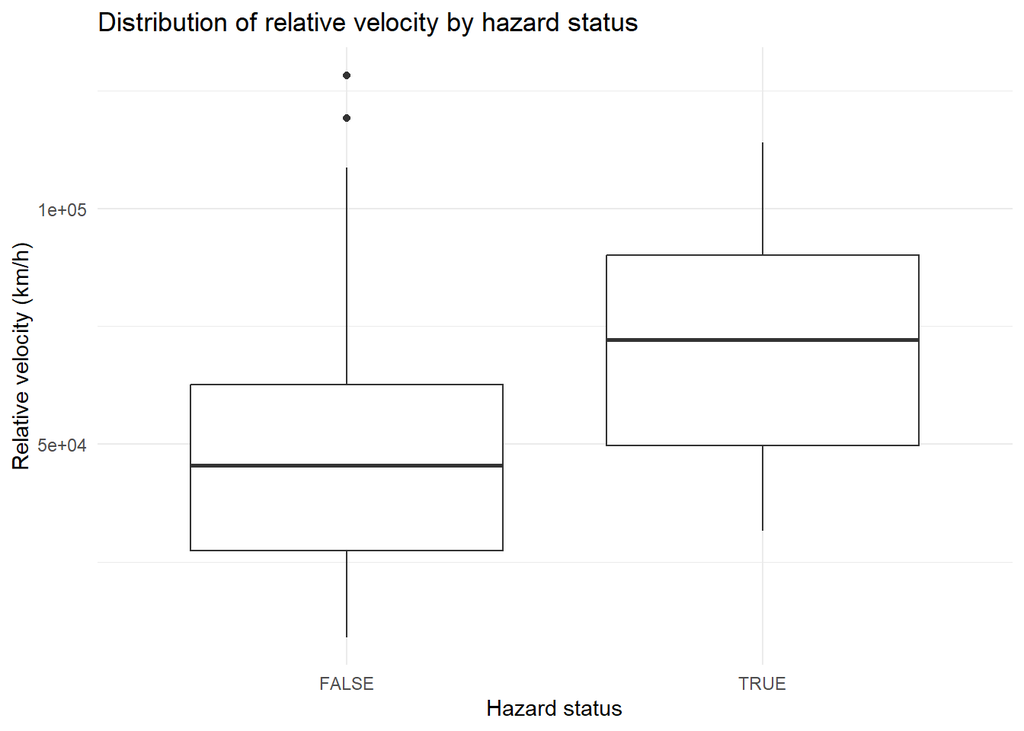

```r
asteroids_data |>
  filter(diameter < 1) |>
  group_by(is_hazardous) |>
  ggplot(aes(x = is_hazardous, y = diameter)) +
  geom_boxplot() +
  labs(title = "Distribution of asteroid diameter by hazard status",
       x = "Hazard status", y = "Diameter (km)")

asteroids_data |>
  group_by(is_hazardous) |>
  ggplot(aes(x = is_hazardous, y = relative_velocity)) +
  geom_boxplot() +
  labs(title = "Distribution of relative velocity by hazard status",
       x = "Hazard status", y = "Relative velocity (km/h)")
```

# Part 2

```r
complaints1 <- fread("https://www.consumerfinance.gov/data-research/consumer-complaints/search/api/v1/?format=csv&date_received_min=2023-03-25&date_received_max=2023-09-24&has_narrative=true")
complaints2 <- fread("https://www.consumerfinance.gov/data-research/consumer-complaints/search/api/v1/?format=csv&date_received_min=2023-09-25&date_received_max=2024-03-24&has_narrative=true")
complaints <- rbindlist(list(complaints1, complaints2))
```

To import the data, I had to split my query into two parts to avoid technical issues which I previously encountered. I accessed the data from the API URLs by using `fread` and concatenating the tables using `rbindlist` from the data.table package. Since I am interested in the consumer complaint narratives for later questions, I only retrieved data with non-empty narratives.

The data has 428300 observations of 18 variables, which are all of type character. The variables describe the complaint ID, date of complaint, product, issue, company name, and company response, among other information.

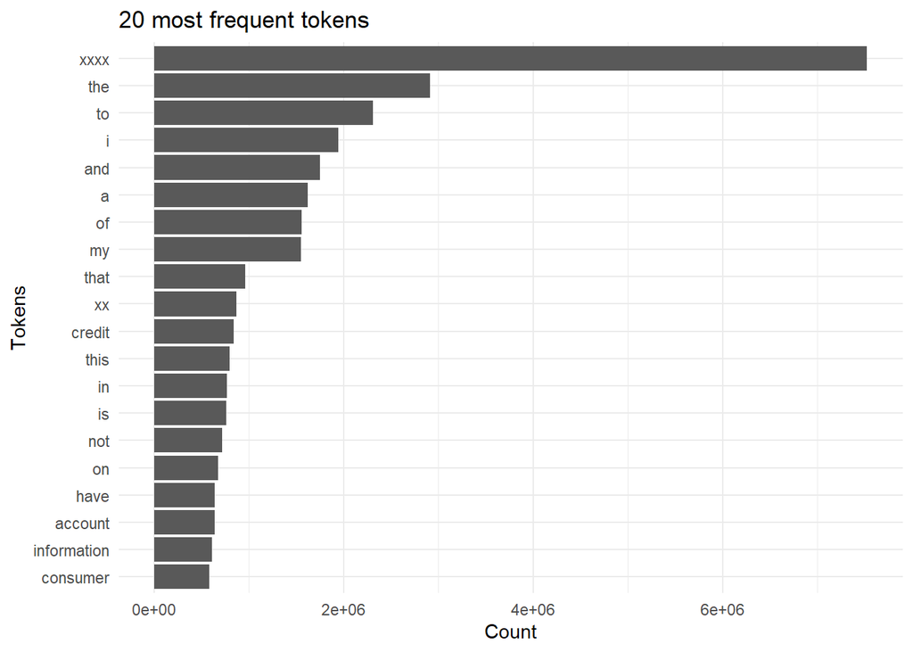

```r
# Tokenizing the complaints
tokens <- complaints |>
  select(`Consumer complaint narrative`) |>
  unnest_tokens(word, `Consumer complaint narrative`) |>
  count(word) |>
  arrange(across(n, desc))

# Plotting the tokens
tokens |>
  head(20) |>
  ggplot(aes(x = reorder(word, n), y = n)) +
  geom_bar(stat = 'identity') +
  coord_flip() +
  labs(title = "20 most frequent tokens", x = "Tokens", y = "Count")
```

The 20 most frequently occurring tokens are mainly stopwords and fillers such as “xxxx”, “the”, “and”, etc. Four of the tokens, which are “credit”, “account”, “information”, and “consumer”, are more informative terms. “Credit” and “account” show that the data is primarily concerned with complaints about financial and banking products.

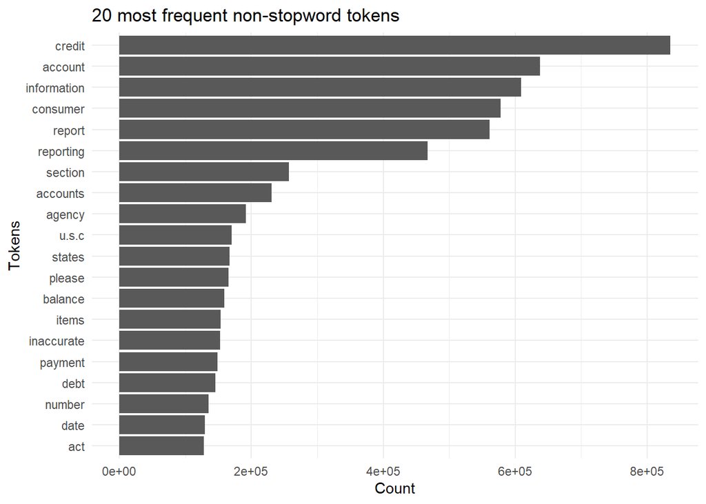

```r
stopwords <- c(stopwords("english"), "also", "can", "without")

# Tokenizing the complaints without stopwords
tokens2 <- complaints |>
  select(`Consumer complaint narrative`) |>
  unnest_tokens(word, `Consumer complaint narrative`) |>
  filter(!word %in% stopwords) |>
  filter(!grepl("^[[:digit:]]+", word)) |>
  filter(!grepl("^[Xx]+", word)) |>
  count(word) |>
  arrange(across(n, desc))

# Plotting the tokens
tokens2 |>
  head(20) |>
  ggplot(aes(x = reorder(word, n), y = n)) +
  geom_bar(stat = 'identity') +
  coord_flip() +
  labs(title = "20 most frequent non-stopword tokens", x = "Tokens",
       y = "Count")
```

After removing stopwords, the most frequently occurring tokens are noticeably different and more informative, with terms such as “accounts”, “agency”, “payment”, and even “please”. Most of them are related to financial and banking products, supporting my previous observation. (Note that “u.s.c” likely means the United States Code, which contains federal laws regarding banking.) The five most common non-stopword tokens for the complaints are “credit”, “account”, “information”, “consumer”, and “report”.

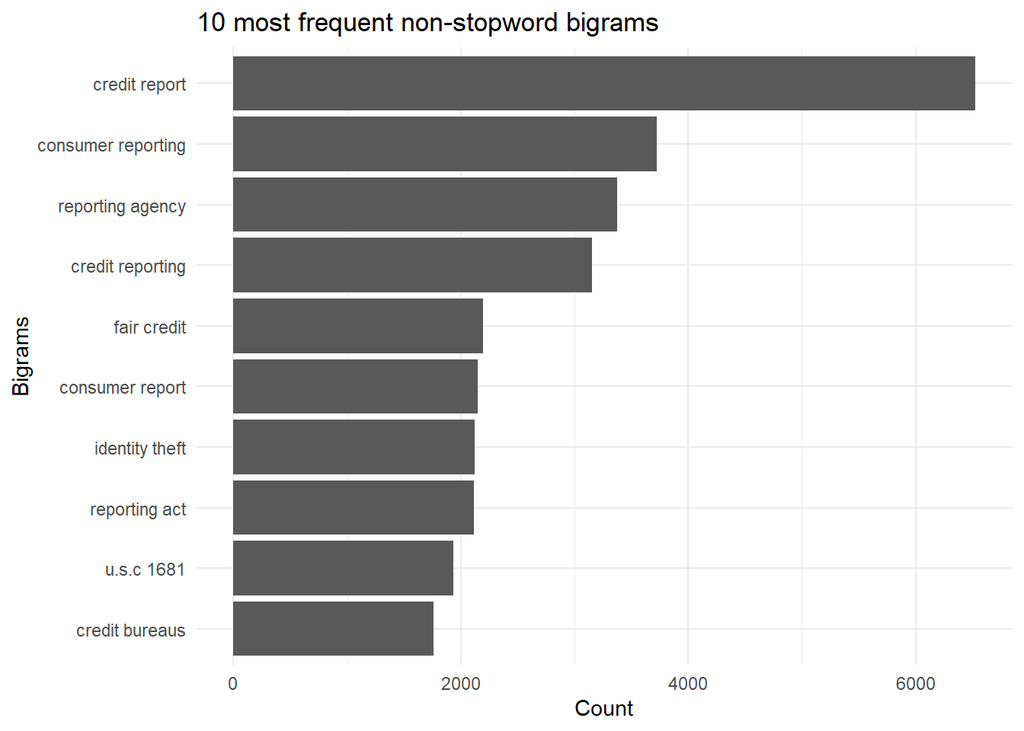

```r
sw_start <- paste0("^", paste(stopwords, collapse = " |^"), "$")
sw_end <- paste0("", paste(stopwords, collapse = "$| "), "$")

# Extracting the bigrams without stopwords
tokens_bigram <- complaints |>
  sample_n(10000) |>
  select(`Consumer complaint narrative`) |>
  unnest_tokens(ngram, `Consumer complaint narrative`,
                token = "ngrams", n = 2) |>
  filter(!grepl(sw_start, ngram, ignore.case = TRUE)) |>
  filter(!grepl(sw_end, ngram, ignore.case = TRUE)) |>
  filter(!grepl("^[[:digit:]]+", ngram)) |>
  filter(!grepl("^[Xx]+", ngram)) |>
  count(ngram) |>
  arrange(across(n, desc))

# Plotting the bigrams
tokens_bigram |>
  head(10) |>
  ggplot(aes(x = reorder(ngram, n), y = n)) +
  geom_bar(stat = 'identity') +
  coord_flip() +
  labs(title = "10 most frequent non-stopword bigrams", x = "Bigrams",
       y = "Count")
```

Due to technical constraints, I randomly selected 10000 complaints from the dataset and extracted the bigrams from this subset.

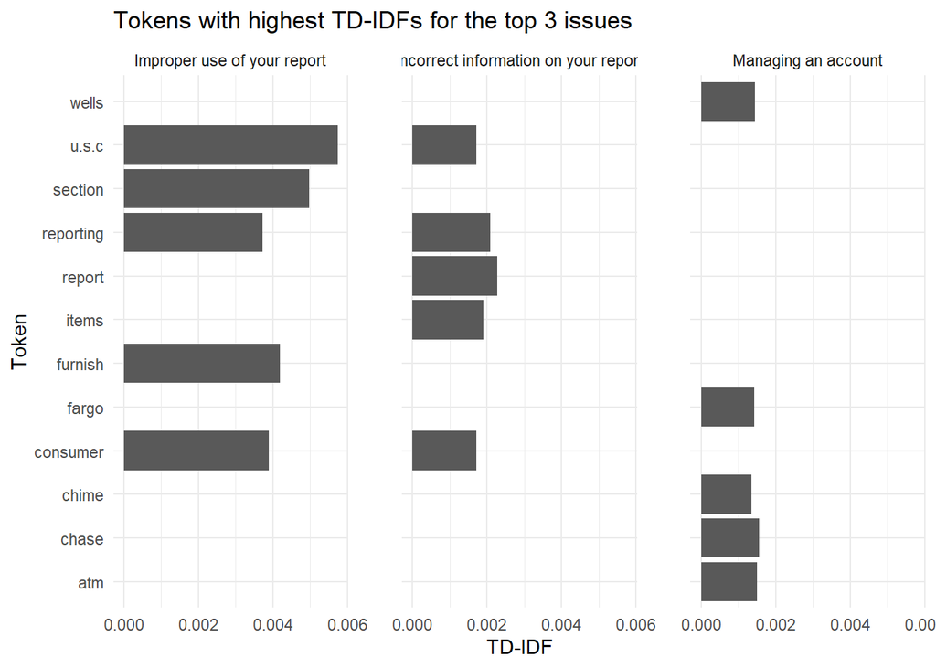

```r
# Calculating the TD-IDF values
td_idf <- complaints |>
  select(`Consumer complaint narrative`, Issue) |>
  unnest_tokens(word, `Consumer complaint narrative`) |>
  filter(!word %in% stopwords) |>
  filter(!grepl("^[[:digit:]]+", word)) |>
  filter(!grepl("^[Xx]+", word)) |>
  count(word, Issue) |>
  bind_tf_idf(word, Issue, n) |>
  arrange(desc(tf_idf))

# Getting the top 3 issues
top_issues <- td_idf |>
  group_by(Issue) |>
  count() |>
  arrange(across(n, desc)) |>
  head(3) |>
  select(Issue) |>
  as.list()

top_issues <- top_issues[[1]]

# Plotting the highest TF-IDF values per issue
td_idf |>
  filter(Issue %in% top_issues) |>
  group_by(Issue) |>
  slice_max(order_by = tf_idf, n = 5) |>
  ggplot(aes(x = word, y = tf_idf)) +
  geom_bar(stat = 'identity') +
  coord_flip() +
  facet_wrap(~ Issue) +
  theme(panel.spacing = unit(2, "lines")) +
  labs(title = "Tokens with highest TD-IDFs for the top 3 issues",
       x = "Token", y = "TD-IDF")
```

These results are mostly different from my results (without stopwords) in question 2. In particular, only “report” and “consumer” are among the top 5 most frequent tokens and the tokens with the highest TD-IDFs. Other words, namely “u.s.c”, “section”, “reporting”, and “items”, are among the top 20 most frequent tokens and the tokens with the highest TD-IDFs. On the other hand, words such as “chime” and “atm” have high TD-IDFs but do not appear in the top 20 most frequent tokens.

Notice that some tokens with high TD-IDFs such as “u.s.c” and “reporting” are common to more than one issue.